# Reporte del Alumnado Ingeniería UA

Tomás López & Katia Cammisa

28/06/2019

# **Interpretación de los Datos**

## Introducción

La siguiente información se basa en los datos proporcionados por la facultad sobre todos los alumnos que se anotaron en el curso de ingreso durante 2018 y 2019. En primer lugar optimizamos los datos para facilitar su procesamiento y lectura. Por ejemplo unificamos mismo significado en una palabra, ya que en varios casos, como baja, lo expresaban con sinónimos. Luego hicimos varios gráficos para poder ir interpretando toda la información y asi lograr sacar varias conclusiones.

## Información Básica General

Al diferenciar estos datos básicos entre 2018 y 2019 se pueden apreciar tres cosas:

- El porcentaje de matriculados se mantuvo.
- Aumentó el porcentaje de mujeres lo cual se debe a la nueva carrera Biomédica.
- Aumentó ligeramente el porcentaje becas otorgadas.

### 2018

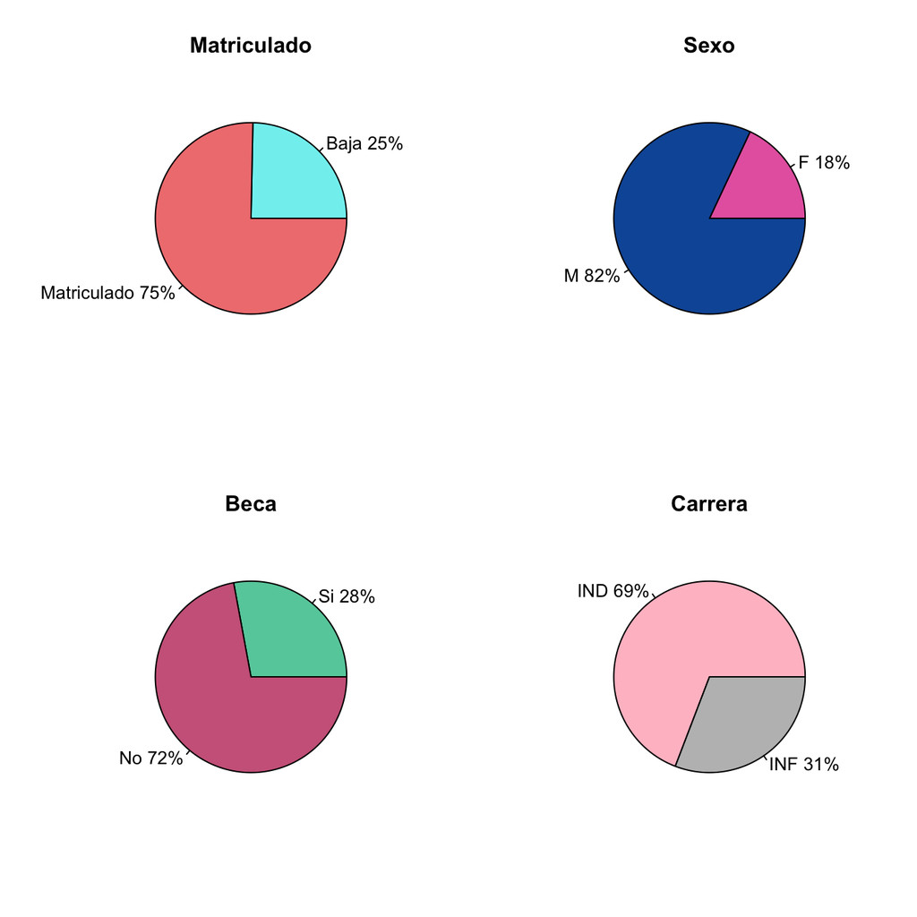

### 2019

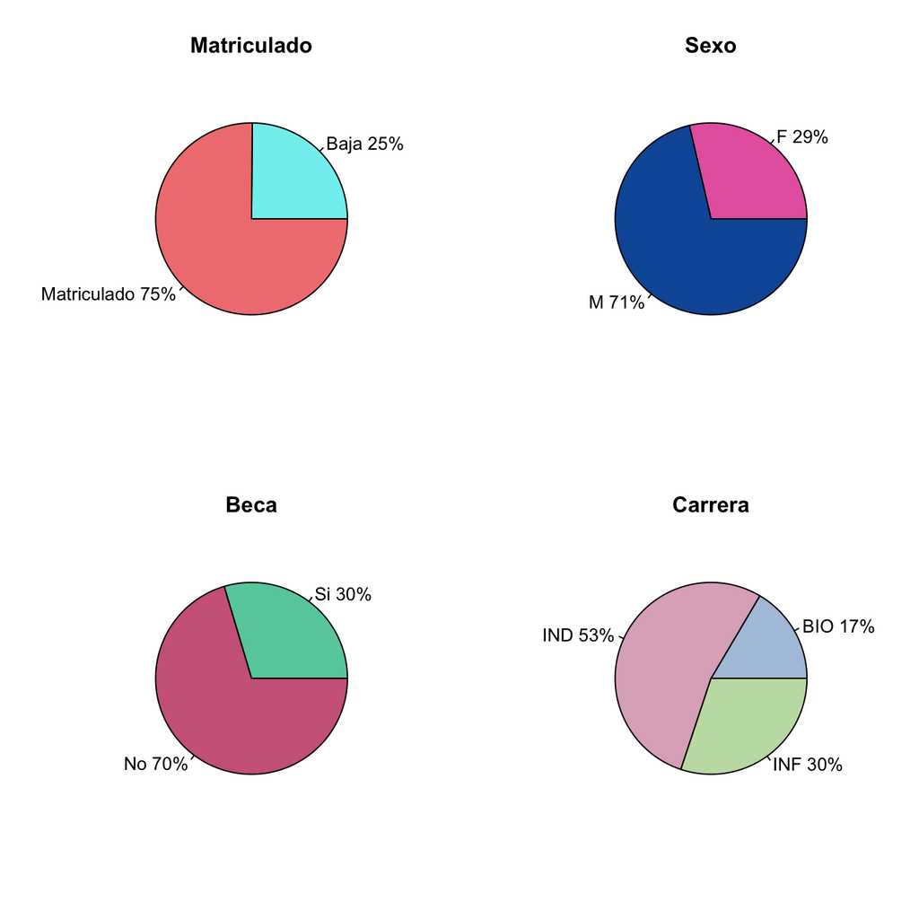

## Curso de Ingreso elegido

En este grafico se tiene en cuenta a todas las personas que se inscribieron en el curso. El principal cambio que se ve entre 2018 y 2019 es que disminuyó la elección de febrero y aumentó la de octubre.

### 2018

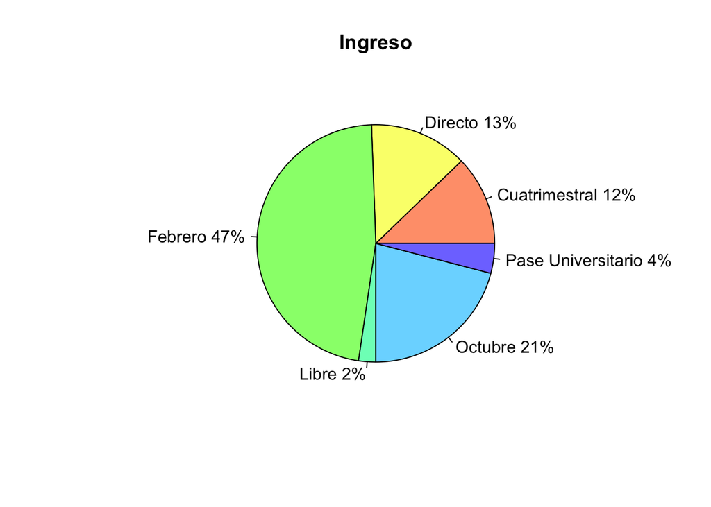

### 2019

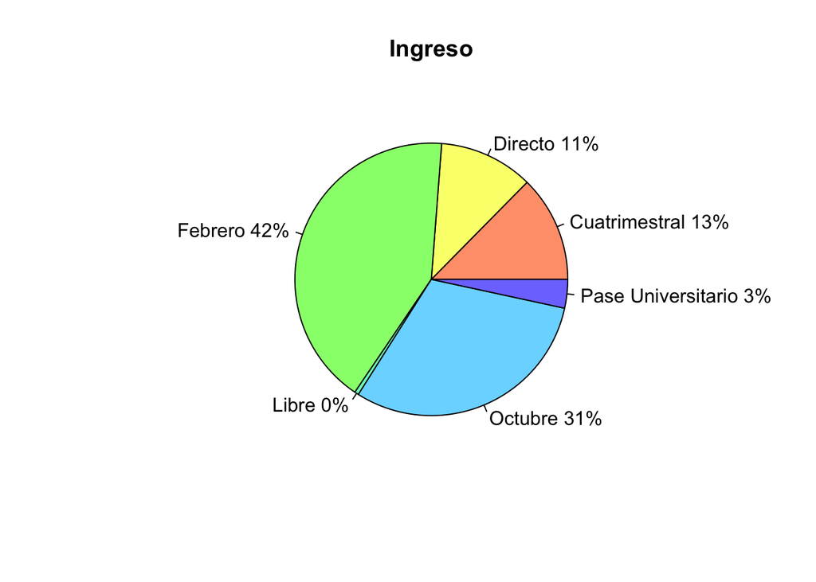

## Estado dado el sexo

En 2018 hubo un menor porcentaje de bajas en mujeres que en varones. En cambio en 2019 aumentan signifcativamente las bajas de mujeres y las de varones disminuyen en menor medida.

### 2018

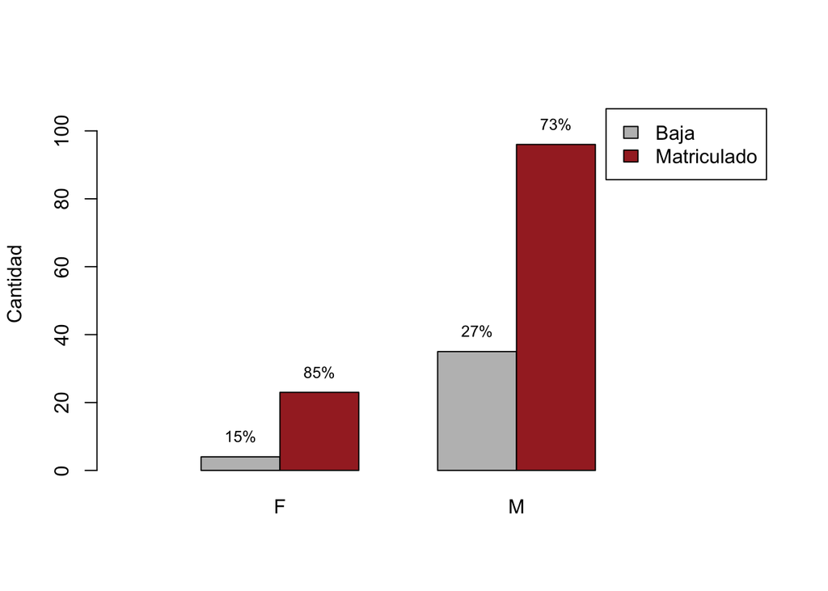

### 2019

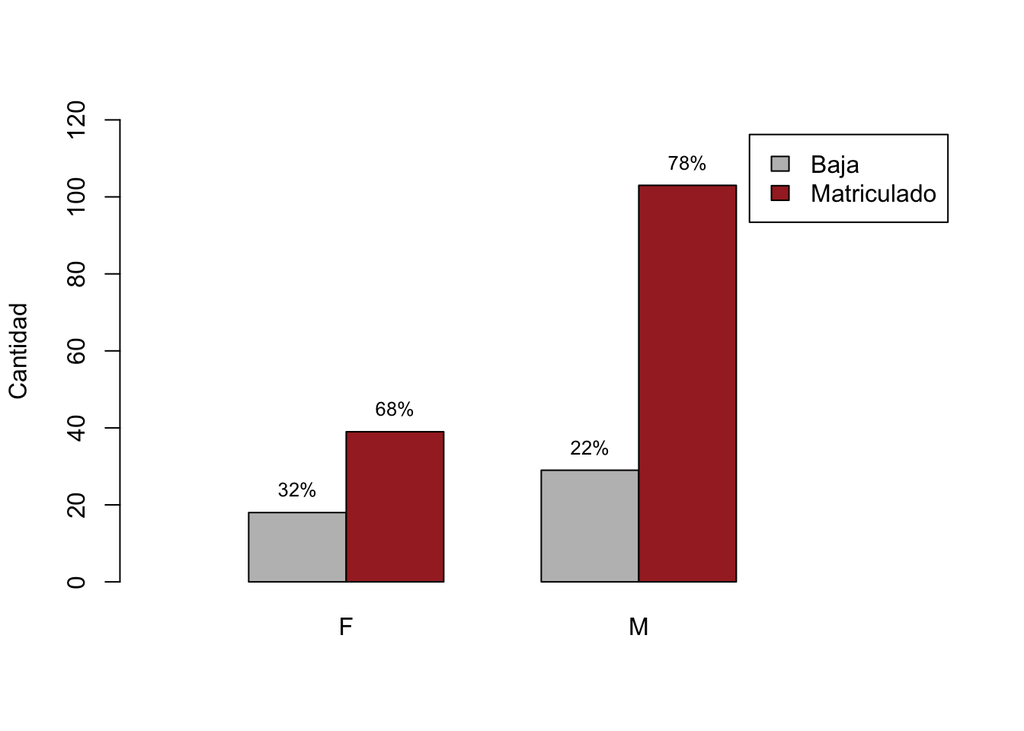

## Carrera dado el sexo

En estos graficos se puede ver la cantidad y el porcentaje de varones y mujeres por carrera. Se utilizan distintos graficos para diferenciar en uno a todas las personas inscriptas, es decir a todos los que se anotaron en el curso, y en el otro unicamente a las personas matriculadas, que son las que aprobaron el curso de ingreso. La informacion que se rescata es que los porcentajes entre inscriptos y matriculados se mantienen con la excepción de Biomédica que aumenta el porcentaje de hombres.

### 2018

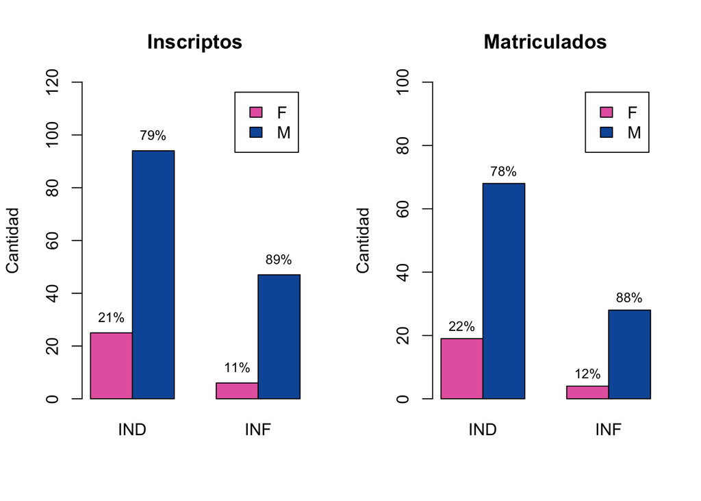

### 2019

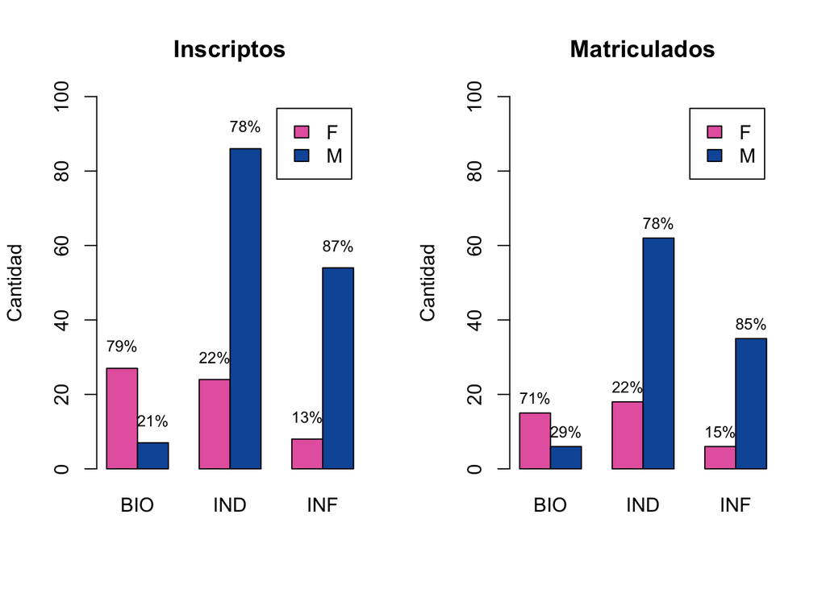

## Estado por Curso de Ingreso

En estos graficos analizamos la cantidad y el porcentaje de matriculados por cada tipo de curso de ingreso. Se rescata la siguiente información:

- El buen rendimiento en febrero, el cual empeora en 2019.
- El bajo rendimiento en el cuatrimestral teniendo en cuenta su duración.
- La gran mejora del rendimiento en octubre durante 2019.

### 2018

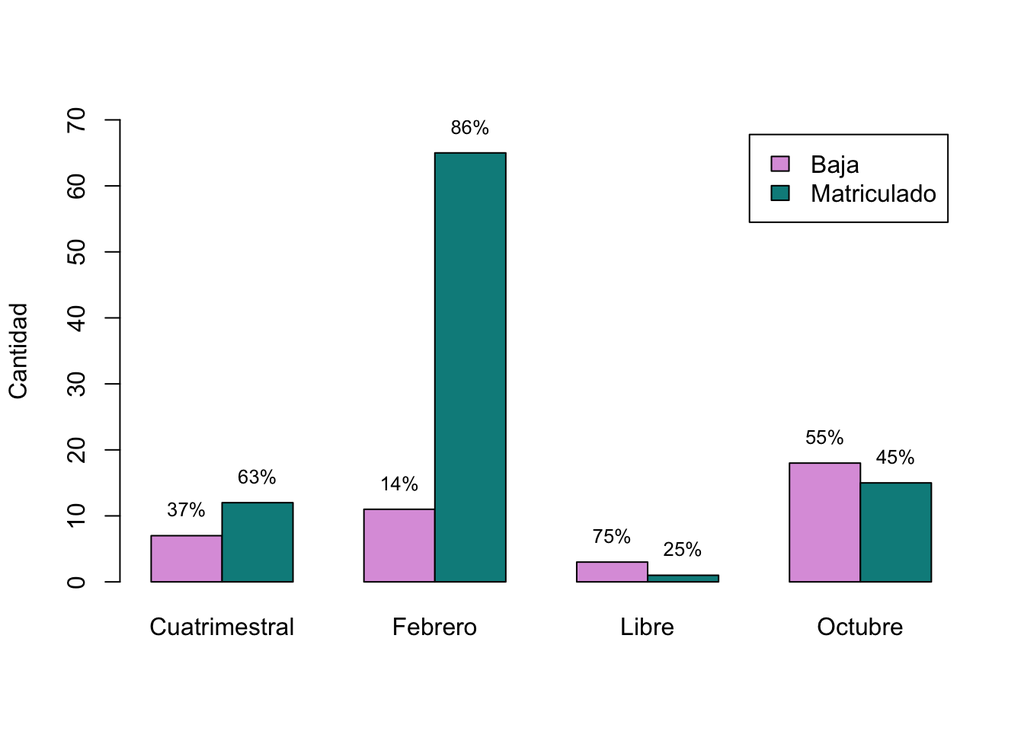

### 2019

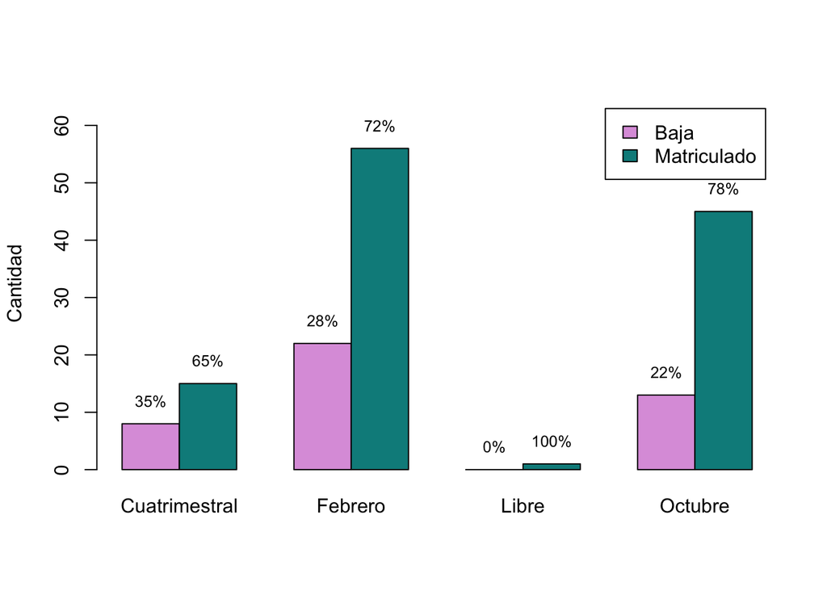

## Notas Curso de Ingreso

En estos graficos se analizan las notas del curso de ingreso, diferenciando año y sexo. Las principales conclusiones que se evidencian son las siguientes:

- En 2018 el rendimiento de las mujeres es mejor al de varones.
- En 2019 las mujeres empeoran y los varones mejoran de esta marena se equilibra mas el rendimiento de ambos.
- El rendimiento en física de las mujeres en ambos años es mejor al de matemática. El de los hombres también es mejor en 2018, pero en 2019 empeoran en física y mejoran en matemática.
- El rendimiento de las mujeres en matemática en 2018 es mejor que el de los hombres y en 2019 se equilibra.
- El rendimiento de las mujeres en física en ambos años es mejor que el de los hombres.

### Promedio

#### 2018

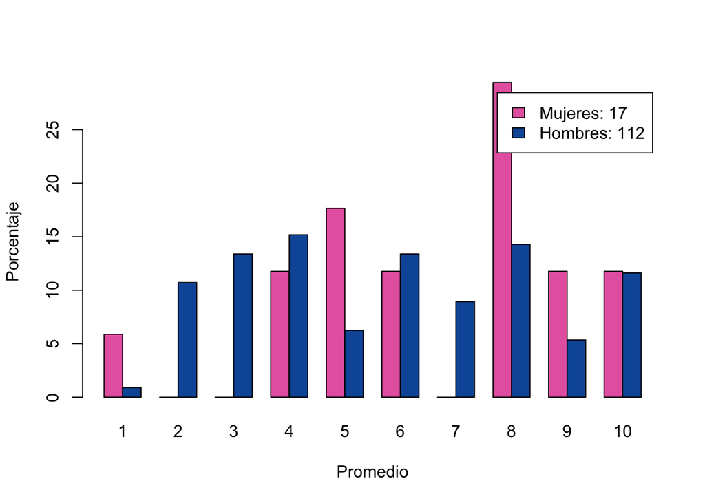

#### 2019

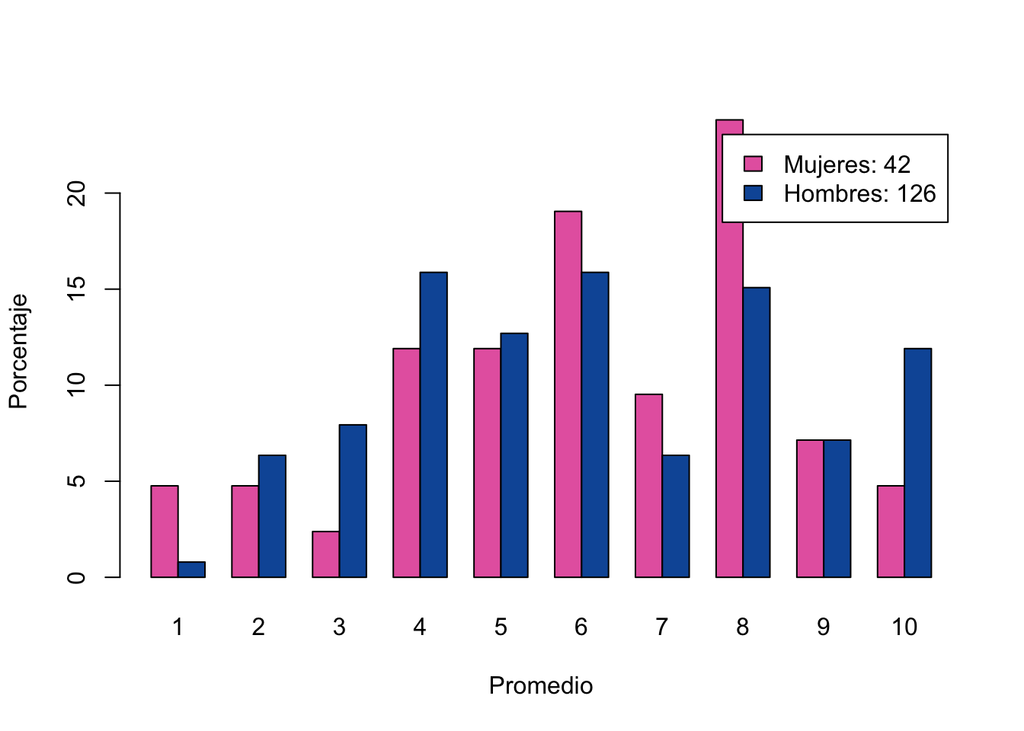

### Matematica

#### 2018

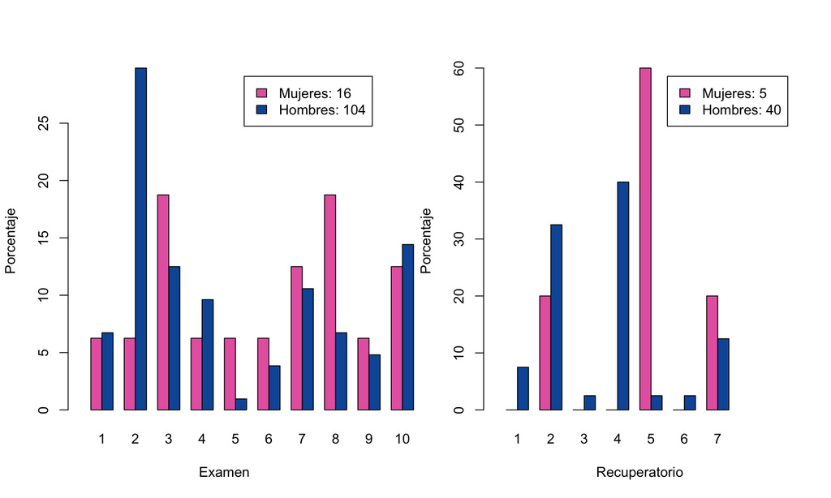

#### 2019

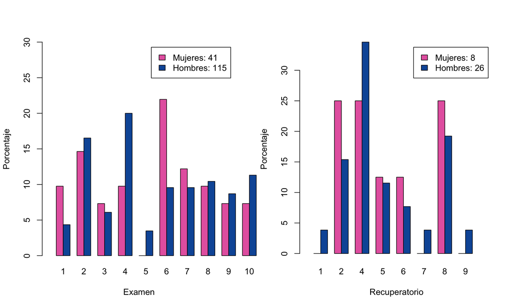

### Fisica

#### 2018

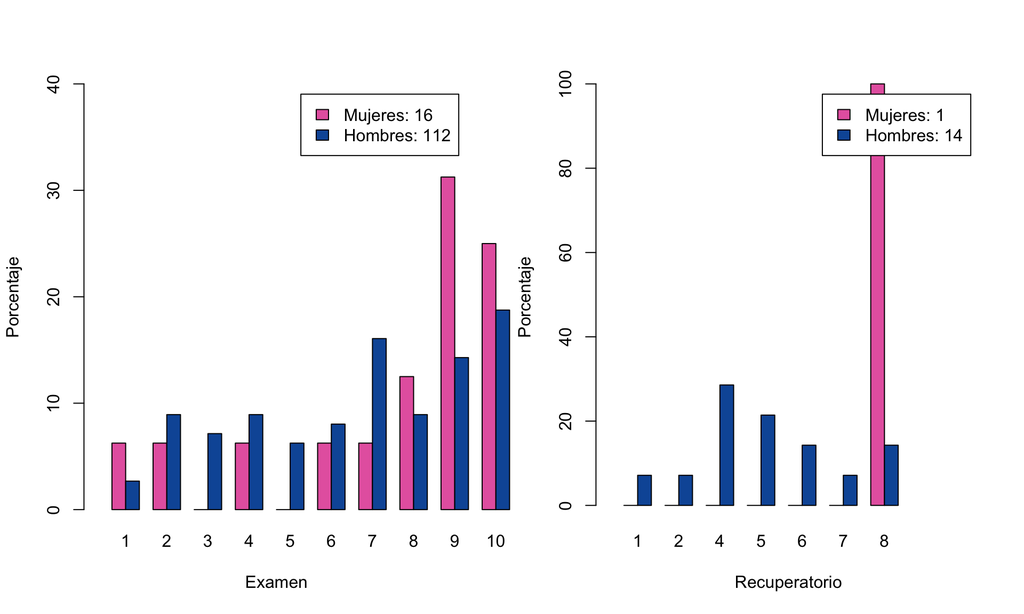

#### 2019

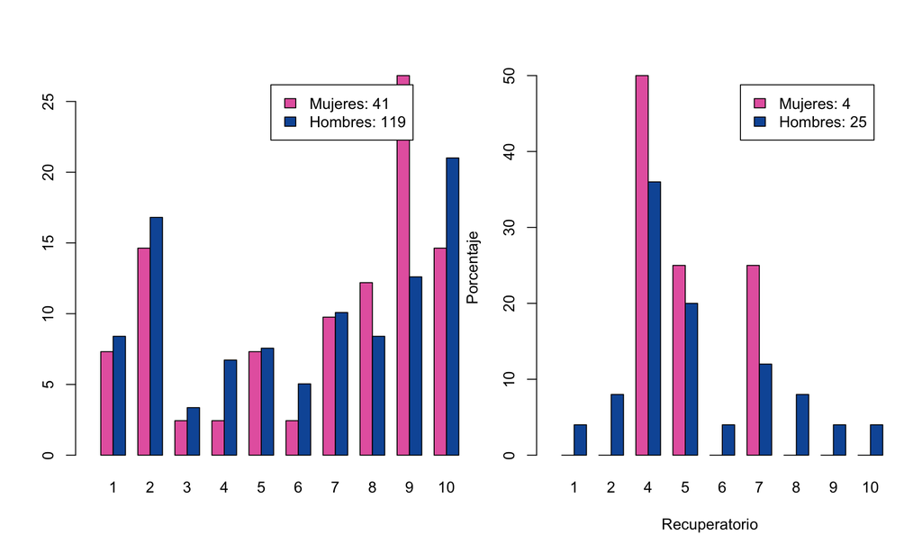

# **Predictor Académico**

## Introducción

Utilizando la información brindada por la facultad acerca de las notas de Álgebra, Análisis e Introducción a la Programación, y si finalmente dejaron o continuaron en la carrera, construimos un predictor basado en cuatro modelos distintos. Este consiste en que dadas las notas de estas tres materias proporciona información sobre el futuro del alumno en la carrera.

Funcionamiento: El predictor que armamos se basa en tomar el 75% de los datos que nos proporcionaron para armar los modelos y con el 25% restante, se prueba la exactitud del predictor. Asi es como se consigue la confiabilidad del modelo. Este proceso lo repite aproximadamente 20 veces, lo que aumenta la precisión del predictor. Generamos varios modelos para luego poder comparar los resultados entre ellos y obtener una predicción aún más certera.

## Características de los Modelos

Nuestro trabajo cuenta con 4 modelos de predicción. Cada uno tiene sus prioridades en elección de materias y confiabilidad propia. Esto significa que hay modelos que priorizan el rendimiento en una materia sobre otra al generar la predicción y cada modelo cuenta con un cierto nivel de confiabilidad que informa cual es la probabilidad de que la predicción sea correcta. También se puede apreciar su confiabilidad analizando sus Matrices de Confusión que proporcionan informacion acerca de la relación entre las predicciones realizadas por el modelo y los datos reales.

Los modelos son:

- Neural Network (NNET): Este modelo toma mucha información del resultado de Análisis y los exámenes de Álgebra, mientras que casi no utiliza las notas de Introducción a la Programación. Este modelo cuenta con una confiabilidad del 93% y tiene un p-valor de 0,003.

| NNET | Predice que no deja la carrera | Predice que deja la carrera |
| --- | --- | --- |
| Realmente no deja la carrera | 19 | 1 |
| Realmente deja la carrera | 0 | 6 |

- Generalized Boosted Regression Modeling (GBM): Este modelo le da mucha importancia al resultado en el exámen de Introducción a la Programación y algo de importancia al rendimiento en Álgebra mientras que las notas de Análisis casi no las toma en cuenta. El nivel de confiabilidad que proporciona este modelo es de 90% y tiene un p-valor de 0,015.

| GBM | Predice que no deja la carrera | Predice que deja la carrera |
| --- | --- | --- |
| Realmente no deja la carrera | 18 | 1 |
| Realmente deja la carrera | 1 | 6 |

- Generalized Linear Modeling (GLM): Este modelo, por el contrario del anterior, le da mucha importancia al resultado del exámen de Álgebra e Introducción a la Programación mientras que casi no toma en cuenta el rendimiento en el exámen de Análisis. Este modelo cuenta con una confiabilidad del 90% y tiene un p-valor de 0,015.

| GLM | Predice que no deja la carrera | Predice que deja la carrera |
| --- | --- | --- |
| Realmente no deja la carrera | 18 | 1 |
| Realmente deja la carrera | 1 | 6 |

- Random Forest (RF): Este modelo se asemeja mucho al GBM ya que toma mucha información de el exámen de Introducción a la Programación con la diferencia de que también se basa en las notas de Análisis y un poco en las de Álgebra. Este modelo cuenta con una confiabilidad del 83% y tiene un p-valor de 0,05.

| RF | Predice que no deja la carrera | Predice que deja la carrera |
| --- | --- | --- |
| Realmente no deja la carrera | 18 | 2 |
| Realmente deja la carrera | 1 | 5 |

## Conclusiones

Tan solo con los datos proporcionados por las matrices de confusión, podemos llegar a la conclusión de que el modelo con la mayor exactitud es el NNET aunque los modelos GBM y GLM son muy certeros tambien. Mientras que RF es el menos certero, como probaremos a continuación con algunos ejemplos de predicciones que generamos.

### Ejemplo 1

Un estudiante con las siguientes notas:

- Primer parcial de Álgebra: 4
- Segundo parcial de Álgebra: 4
- Primer parcial de Análisis: 1
- Primer parcial de Introducción a la Programación: 1

Obtiene los siguientes resultados dependiendo del modelo:

GBM –> Se queda en la carrera

GLM –> Deja la carrera

NNET –> Se queda en la carrera

RF –> Se queda en la carrera

### Ejemplo 2

Un estudiante con las siguientes notas:

- Primer parcial de Álgebra: 1
- Segundo parcial de Álgebra: 2
- Primer parcial de Análisis: 1
- Primer parcial de Introducción a la Programación: 10

Obtiene los siguientes resultados dependiendo del modelo:

GBM –> Deja la carrera

GLM –> Deja la carrera

NNET –> Deja la carrera

RF –> Se queda en la carrera

Este resultado es muy lógico en los primeros 3 modelos, aunque se nota una gran falla en el modelo RF. Esta es la razón de generar varios modelos, para poder comparar entre ellos los resultados y no guiarse con uno solo.

### Ejemplo 3

Un estudiante con las siguientes notas:

- Primer parcial de Álgebra: 1
- Segundo parcial de Álgebra: 1
- Primer parcial de Análisis: 10
- Primer parcial de Introducción a la Programación: 1

Obtiene los siguientes resultados dependiendo del modelo:

GBM –> Deja la carrera

GLM –> Se queda en la carrera

NNET –> Se queda en la carrera

RF –> Se queda en la carrera

Estos resultados se deben a que tanto el modelo NNET como el RF, le dan mucha importancia al exámen de Análisis mientras que el GBM casi no lo toma en cuenta.

### Ejemplo 4

Un estudiante con las siguientes notas:

- Primer parcial de Álgebra: 1
- Segundo parcial de Álgebra: 1
- Primer parcial de Análisis: 7
- Primer parcial de Introducción a la Programación: 7

Obtiene los siguientes resultados dependiendo del modelo:

GBM –> Se queda en la carrera

GLM –> Se queda en la carrera

NNET –> Se queda en la carrera

RF –> Se queda en la carrera